# Conditional Probability

Author

Jeffrey Smith

Published

February 17, 2025

**Abstract:**

This is a technical blog post of **both** an HTML file *and* [.qmd file](https://jysmochi.github.io/data_505_hw/naivebayes.qmd) hosted on GitHub pages.

# 1. Setup

**Step Up Code:**

```r
sh <- suppressPackageStartupMessages
sh(library(tidyverse))
sh(library(caret))
sh(library(naivebayes))
sh(library(tidytext))
sh(library(scales))
sh(library(thematic))
thematic_rmd(bg = "#111", fg = "#eee", accent = "#eee")
wine <- readRDS(gzcon(url("https://github.com/cd-public/D505/raw/master/dat/pinot.rds")))
```

# 2. Conditional Probability

Calculate the probability that a Pinot comes from Burgundy given it has the word ‘fruit’ in the description.

$$P({\rm Burgundy}~|~{\rm Fruit})$$

```r
wine = wine %>%
  mutate(description = tolower(description))

# going after P(Burgundy and Fruit)
n = nrow(wine)
burgundyfruit = wine %>%
  filter(province == "Burgundy") %>%
  mutate(hasfruit = str_detect(description, "fruit"))
num_burgundyfruit = sum(burgundyfruit$hasfruit)
prob_burgundyfruit = num_burgundyfruit / n
# going after P(Fruit)
fruity = wine %>%
  mutate(hasfruit = str_detect(description, "fruit"))
num_fruit = sum(fruity$hasfruit)
prob_fruit = num_fruit / n
# so by Bayes Theorem
prob_burgundy_given_fruit = prob_burgundyfruit / prob_fruit
print(prob_burgundy_given_fruit)
```

```
[1] 0.2184909
```

# 3. Naive Bayes Algorithm

We train a naive bayes algorithm to classify a wine’s province using: 1. An 80-20 train-test split. 2. Three features engineered from the description 3. 5-fold cross validation.

```r
mywine = wine %>%
  mutate(fct_year = factor(year)) %>%
  mutate(mycherry = str_detect(description, "cherry")) %>%
  mutate(mytannins = str_detect(description, "tannins")) %>%
  mutate(myadhd = str_detect(description, "concentrated")) %>%
  select(-description, year, id)

set.seed(101) # smallest three digit prime
this_and_that = createDataPartition(mywine$province, p = 0.80, list = FALSE)
train = mywine[this_and_that,]
test = mywine[-this_and_that,]

fit <- train(province ~ .,
             data = train,
             method = "naive_bayes",
             metric = "Kappa",
             trControl = trainControl(method = "cv", number = 5))
print(fit)
```

```
Naive Bayes

6707 samples
   8 predictor
   6 classes: 'Burgundy', 'California', 'Casablanca_Valley', 'Marlborough', 'New_York', 'Oregon'

No pre-processing
Resampling: Cross-Validated (5 fold)
Summary of sample sizes: 5365, 5366, 5366, 5366, 5365
Resampling results across tuning parameters:

  usekernel  Accuracy   Kappa
  FALSE      0.4854618  0.15190460
   TRUE      0.3757060  0.05509722

Tuning parameter 'laplace' was held constant at a value of 0
Tuning
 parameter 'adjust' was held constant at a value of 1
Kappa was used to select the optimal model using the largest value.
The final values used for the model were laplace = 0, usekernel = FALSE
 and adjust = 1.
```

# 4. Frequency Differences

We find the three words that most distinguish New York Pinots from all other Pinots.

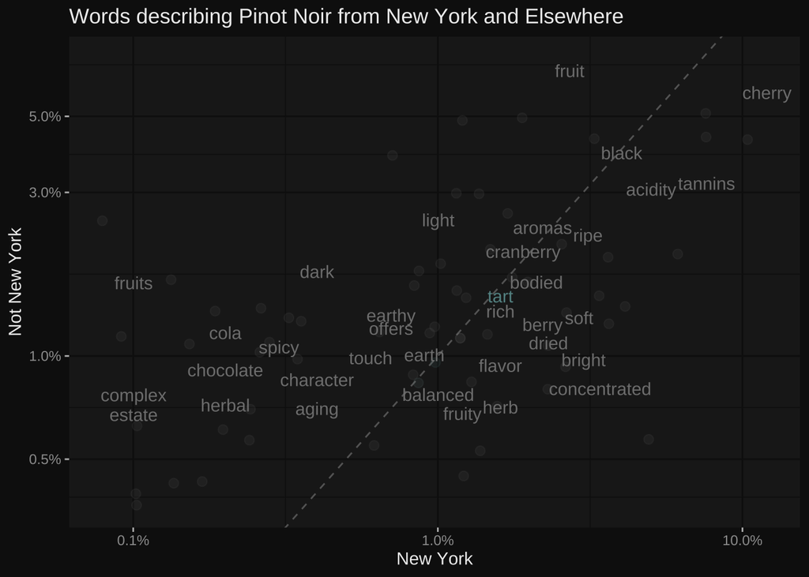

```r
nywine = wine %>%
  mutate(province = ifelse(province == "New_York", "NY", "not_NY"))

wtxt <- nywine %>%
  unnest_tokens(word, description) %>%
  anti_join(stop_words) %>%
  filter(str_detect(string = word, pattern = "[a-z+]")) %>%  # get rid weird non alphas
  filter(str_length(word)>3) %>%  # get rid of strings shorter than 3 characters
  group_by(word) %>%
  mutate(total=n()) %>%
  ungroup()
dtxt <- wtxt %>%
  filter(province=="NY" | province=="not_NY") %>%
  filter(!(word %in% c("wine","pinot","drink","noir","vineyard","palate","notes","flavors","bottling","bottle","finish"))) %>%
  filter(total > 400) %>%
  group_by(province, word) %>%
  count() %>%
  group_by(province) %>%
  mutate(proportion = n / sum(n)) %>%
  pivot_wider(id_cols = word, names_from = province, values_from = proportion) %>%
  mutate(diff=NY-not_NY)

smol_pain = wtxt %>%
    filter(province=="NY" | province=="not_NY") %>%
    filter(!(word %in% c("wine","pinot","drink","noir","vineyard","palate","notes","flavors","bottling"))) %>%
    filter(total > 400) %>%
    group_by(province, word) %>%
    count() %>%
    group_by(province) %>%
    mutate(proportion = n / sum(n)) %>%
    pivot_wider(id_cols = word, names_from = province, values_from = proportion) %>%
    ggplot(aes(x = NY, y = not_NY, color = abs(NY - not_NY))) +
    geom_abline(color = "gray40", lty = 2) +
    geom_jitter(alpha = 0.1, size = 2.5, width = 0.3, height = 0.3) +
    geom_text(aes(label = word), check_overlap = TRUE, vjust = 1.5) +
    scale_x_log10(labels = percent_format()) +
    scale_y_log10(labels = percent_format()) +
    scale_color_gradient(limits = c(0, 0.001), low = "darkslategray4", high = "gray75") +
    theme(legend.position="none") +
    labs(x = "New York", y = "Not New York", title = "Words describing Pinot Noir from New York and Elsewhere")

pain = dtxt %>%
  top_n(25, diff) %>%
  mutate(word = reorder(word, diff)) %>%
  ggplot(aes(word, diff)) +
  geom_col() +
  xlab(NULL) +
  coord_flip()

print(smol_pain)
```

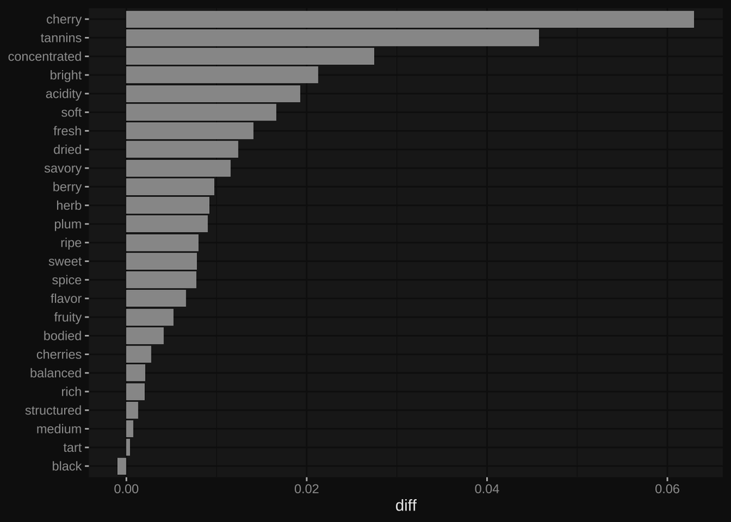

```r
print(pain)
```

> Based on the plots shown above, the three words that most distinguish New York Pinots from all other Pinots are “cherry”, “tannins”, and “concentrated”. I would be amiss to not mention that this word list is generated by proportion with respect to each province, so while “cherry” has the largest difference by proportion between the New York and all other provinces, that does not mean “cherry” appears more by count in New York than it does in other regions, due to differences in region size.

# 5. Extension

Calculate the variance of the logged word-frequency distributions for each province.

```r
vine = wine %>%
  unnest_tokens(word, description) %>%
  anti_join(stop_words) %>%
  filter(word != "wine") %>%
  filter(word != "pinot") %>%
  count(id, word) %>%
  group_by(id) %>%
  mutate(freq = n/sum(n)) %>%
  mutate(exists = (n>0)) %>%
  ungroup() %>%
  group_by(word) %>%
  mutate(total = sum(n)) %>%
  left_join(select(wine, id, province), by = "id") %>%
  count(province, word) %>%
  group_by(province) %>%
  mutate(logn = log(n)) %>%
  group_by(province) %>%
  summarise(variance = var(logn))
print(vine)
```

```
# A tibble: 6 × 2
  province          variance
  <chr>                <dbl>
1 Burgundy             1.69
2 California           1.90
3 Casablanca_Valley    0.858
4 Marlborough          0.894
5 New_York             0.894
6 Oregon               1.74
```